# RNAseq analysis CCS

Etienne Loire

6/1/2019

## Introduction

This document has been generated with a R notebook. It’s purpose is to describe the analysis steps necessary for the results presented in a scientific publication

Our goal is to search for commonly differentialy expressed genes in Aedes aegypti in response to several arbovirus. We will thus used comparison with mock infection responses, at two different infection stages in cell cultures derived from *Aedes aegypti*.

3 replicates of 3 differents controls (mock) and 3 viral infection (dengue, RVF, and Chikungunya) in cell cultures (lines derived from Aedes aegypti) has been performed. Early (24H) and late (6days) response have been measured by RNAseq sequencing. Fastq reads have been analyzed (Cleaning, Mapping on reference and coverage analysis) have been performed by a third party (Montpellier Genomix Platefrom).

## Dataset exploration and quality control

Raw counts tables are present in the “Data” directory under the name “Raw_Counts_RNA-Seq_CetreSossah.txt” Samples are described in the file “sample.csv” in the “Data” directory.

First step is looking at the complete dataset to assess the quality of results

```r
require(tidyverse)
require(edgeR)
require(ggrepel)
require(ggpubr)
require(xlsx)
mytheme = theme_bw()
infos = read.table("Data/sample.csv",sep=",",header=T)
infos = infos %>% mutate(subtype = substring(name,1,nchar(as.character(name))-1))
data  = read.csv("Data/Raw_Counts_RNA-Seq_CetreSossah.txt",sep=",",header=T,row.names = 1)
data %>% dim
```

```
## [1] 19610    36
```

We see that we have raw counts for 19610 genes in 36 samples. First let’s filter all genes with expression values not above 0.5 count per millions reads (cpm) in at least three of the samples.

```r
mdata = as.matrix(data)
mdatacpm = cpm(mdata)
abovecpm = mdatacpm > 0.5
table(rowSums(abovecpm))
```

```
##
##    0    1    2    3    4    5    6    7    8    9   10   11   12   13   14
## 7945 1210  561  389  262  189  197  153  154  139  116  105  126  113  100
##   15   16   17   18   19   20   21   22   23   24   25   26   27   28   29
##   97   89   88   93   98  108   94   90  116  118  118  142  128  132  151
##   30   31   32   33   34   35   36
##  172  164  240  312  436  750 4115
```

```r
keep = rowSums(abovecpm) >= 3
summary(keep)
```

```
##    Mode   FALSE    TRUE
## logical    9716    9894
```

```r
filtmdata = mdata[keep,]
```

9894 genes satisfy this threshold

Now we will look at the library size of each samples and look at a multidimensional scaling plot (MDS) to see if genes expression is less variable among replicates than among groups of samples.

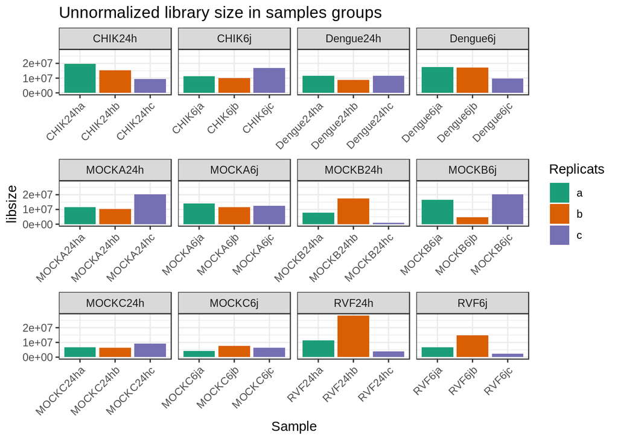

```r
DG = DGEList(counts = filtmdata)
ggplot(data.frame(name = colnames(DG),libsize = DG$samples$lib.size,type = infos$subtype,time=infos$time,sample=infos$sample) %>%
         arrange(.,sample,time) ) + geom_bar(aes(x=name,y=libsize,fill=sample),stat="identity") +
  facet_wrap(~ type,scale="free_x")  + scale_fill_brewer(name="Replicats",palette ="Dark2") + xlab("Sample") +
  mytheme + theme(axis.text.x = element_text(angle=45,hjust =1 )) + ggtitle("Unnormalized library size in samples groups")
```

```r
ggsave("Figures/library_size.pdf")
```

We can already see that somes samples seems to have a lower depth of sequencing when compared to others (Notably MOCKB24hc, MOCKB6jb,MOCKC6ja,RVF24hc,RVF6jc). We will see in the MDS plot if this seems to be a problem.

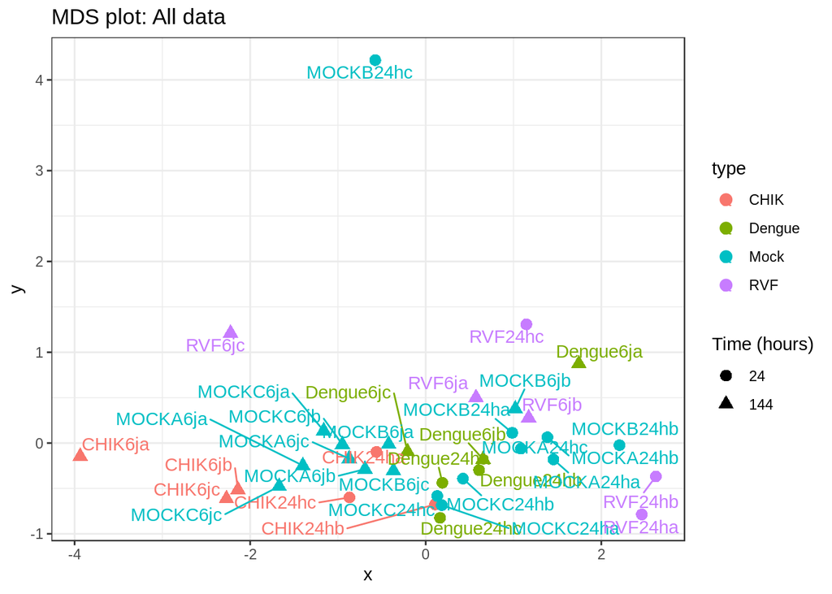

```r
mdata = plotMDS(DG,plot=FALSE)
dfmdf=data.frame(x=mdata$x,y=mdata$y)
dfmdf %>% mutate(name = rownames(dfmdf)) %>% left_join(infos,by="name") %>%
ggplot() +
  geom_point(aes(x=x,y=y,color=type,shape=as.factor(time)),size=3) +
  geom_text_repel(aes(x=x,y=y,color = type,label= name)) +
  scale_shape_discrete("Time (hours)") +
  mytheme + ggtitle("MDS plot: All data")
```

```r
ggsave("Figures/MDS_All_DATA.pdf")
```

We see that there is indeed a problem with some of the cited Samples. Additionnaly, we remark that all Chikungunya samples are grouped with mock samples, indicating a probable experiment failure

## Fitlering of unreliable samples

```r
toremove  = DG$samples %>% mutate(sample=rownames(.)) %>% filter(lib.size<5000000) %>% select(sample)
toremove
```

```
##      sample
## 1 MOCKB24hc
## 2  MOCKB6jb
## 3  MOCKC6ja
## 4   RVF24hc
## 5    RVF6jc
```

```r
fdata = data %>% select(-c("MOCKB6jb","MOCKC6ja","RVF24hc","RVF6jc","MOCKB24hc",
                          "CHIK24ha","CHIK24hb","CHIK24hc","CHIK6ja","CHIK6jb","CHIK6jc"))
mdata = as.matrix(fdata)
mdatacpm = cpm(mdata)
abovecpm = mdatacpm > 0.5
keep = rowSums(abovecpm) >= 3
summary(keep)
```

```
##    Mode   FALSE    TRUE
## logical   10294    9316
```

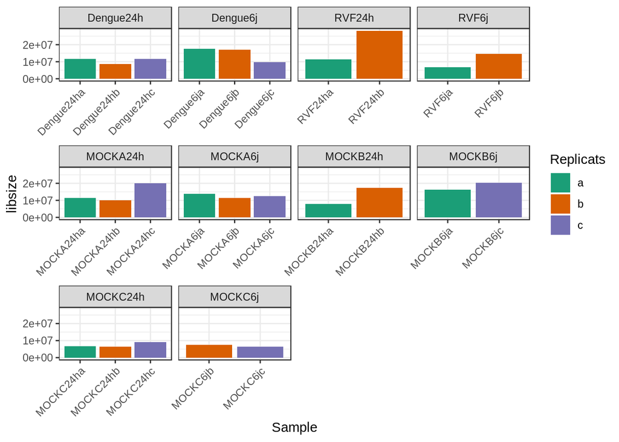

```r
filtmdata = mdata[keep,]
DG = DGEList(counts = filtmdata)
DG = calcNormFactors(DG)
infos = infos %>% filter(!(name %in% c("MOCKB6jb","MOCKC6ja","RVF24hc","RVF6jc","MOCKB24hc",
                 "CHIK24ha","CHIK24hb","CHIK24hc","CHIK6ja","CHIK6jb","CHIK6jc")))
# Reorder factor
infos$type = factor(infos$type,levels=c("Dengue","RVF","Mock"))
infos$subtype = factor(infos$subtype,levels=c("Dengue24h","Dengue6j","RVF24h","RVF6j",
                                              "MOCKA24h","MOCKA6j","MOCKB24h","MOCKB6j","MOCKC24h","MOCKC6j"))
ggplot(data.frame(name = colnames(DG),libsize = DG$samples$lib.size,type = infos$subtype,time=infos$time,sample=infos$sample) %>%
         arrange(.,sample,time) ) + geom_bar(aes(x=name,y=libsize,fill=sample),stat="identity") +
  facet_wrap(~ type,scale="free_x")  + scale_fill_brewer(name="Replicats",palette ="Dark2") + xlab("Sample") +
  mytheme + theme(axis.text.x = element_text(angle=45,hjust =1 ))
```

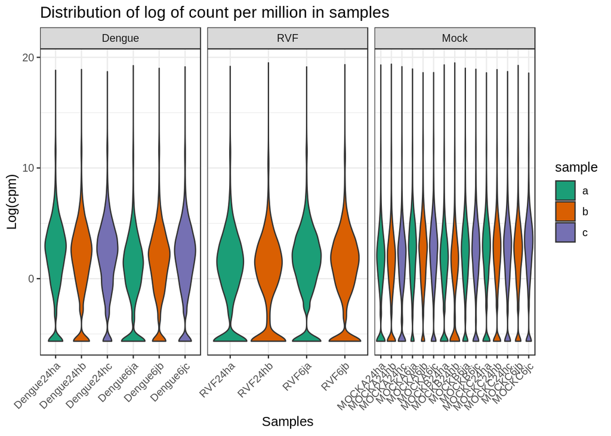

```r
ggsave("Figures/filtered_lib_size.pdf")
logcount = cpm(DG$counts,log=T)
infos$name=as.factor(infos$name)
datalogcpm = data.frame(logcount) %>% gather(name,count) %>% left_join(infos,by = "name")
ggplot(datalogcpm %>% arrange(.,sample,time)) + geom_violin(aes(x=name,y=count,fill=sample))  + facet_wrap(~ type,scale="free_x")  + scale_fill_brewer(palette ="Dark2") + mytheme + theme(axis.text.x = element_text(angle=45,hjust =1 )) + xlab("Samples") + ylab("Log(cpm)") +
  ggtitle("Distribution of log of count per million in samples")
```

```r
ggsave("Figures/LogCPM_violin_count.pdf")
```

Selected samples exhibit a good homogenenity among samples after normalization.

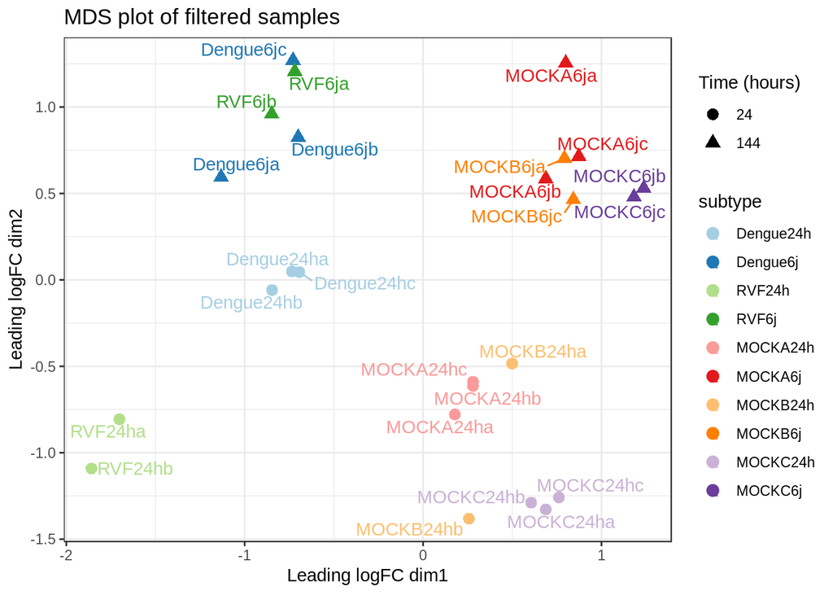

```r
mdata = plotMDS(DG,top=500,plot=FALSE)
dfmdf=data.frame(x=mdata$x,y=mdata$y)
ggplot(dfmdf %>% mutate(name = rownames(dfmdf)) %>% left_join(infos,by="name" )) +
  geom_point(aes(x=x,y=y,color=subtype,shape=as.factor(time)),size=3) +
  geom_text_repel(aes(x=x,y=y,color = subtype,label= name)) +
  scale_shape_discrete("Time (hours)") +
  scale_color_brewer(type="qual",palette="Paired")  + xlab("Leading logFC dim1") +
  ylab("Leading logFC dim2") + mytheme + ggtitle("MDS plot of filtered samples")
```

```r
ggsave("Figures/MDS_GOOD_DATA.pdf")
```

## Differential expression analysis

# GLM fit

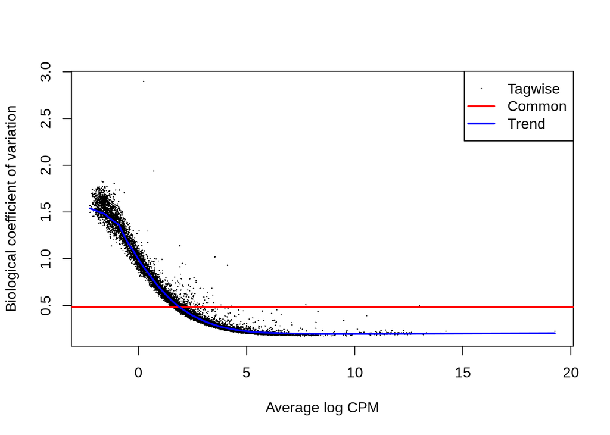

```r
# First get gene annotations
Desc = read.csv("Data/Gene_description.txt",sep="\t",header=T)
Long_description = Desc %>% group_by(NCBI.gene.ID,Gene.name,Gene.description) %>% summarize(GOslims = toString(GOSlim.GOA.Description)) %>% ungroup
colnames(Long_description)[1] = "geneID"
Long_description$geneID =  as.character(Long_description$geneID)
# Design with all biological replicates:
subtype =  as.factor(as.vector(infos$subtype))
design1 = model.matrix(~0+subtype)
DG = estimateDisp(DG,design1,robust = T)
plotBCV(DG)
```

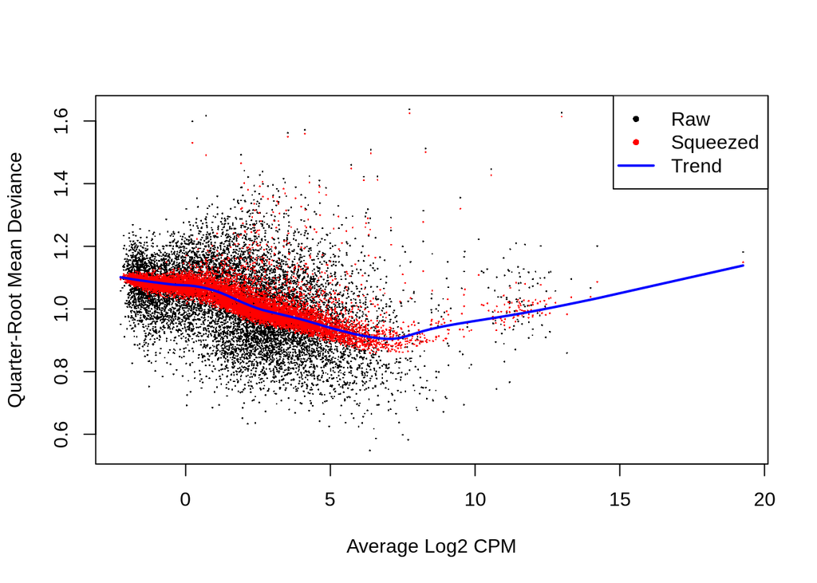

```r
fit <- glmQLFit(DG, design1, robust=TRUE)
plotQLDisp(fit)
```

Here we see that the biological variation (among samples in the same groups) is quite low, suggesting that our selection of samples lead to a clean datasets. Trended variation along gene expression is correct (high, then low as expression values increase). The GLM fit for each genes shows the levels of variation among group, with the empirical Bayes shrinkage around trended variation in red. The fit, from my experience, seems quite good.

# Early viral response

We will compare the expression values at 24H in virus versus mock infection

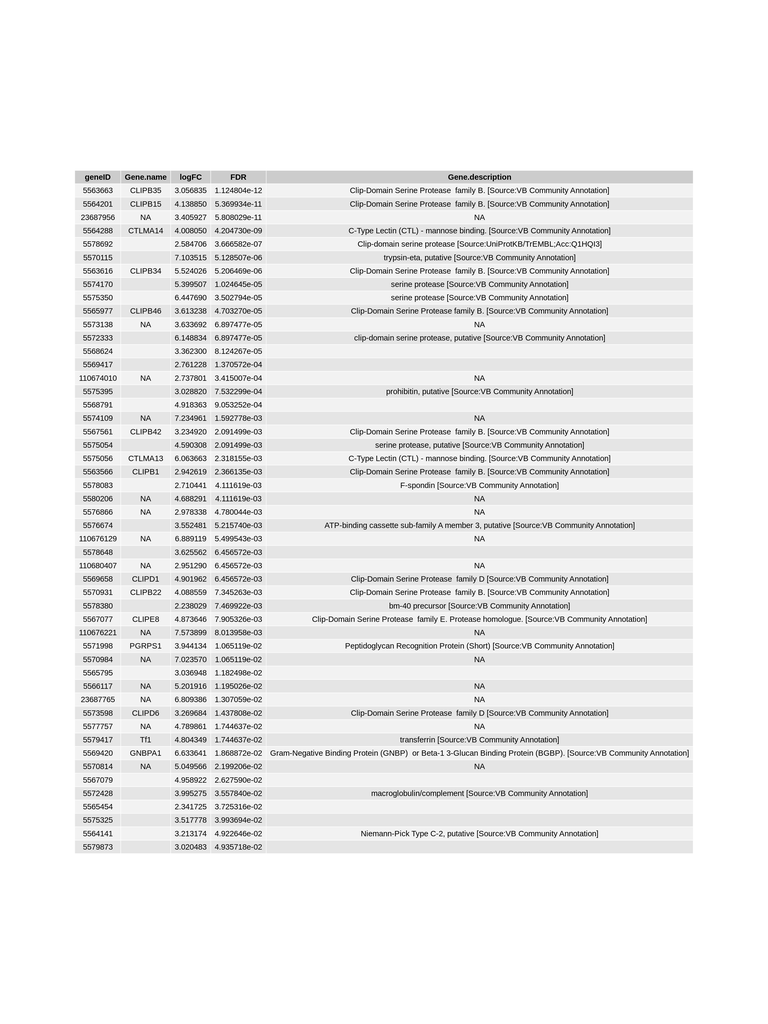

```r
Early <- makeContrasts((0.5*subtypeDengue24h + 0.5*subtypeRVF24h)-(1/3*subtypeMOCKA24h + 1/3*subtypeMOCKB24h + 1/3*subtypeMOCKC24h),levels=design1)
#DG = estimateDisp(DG,design1,robust = T)
fit <- glmQLFit(DG, design1, robust=TRUE)
tr <- glmTreat(fit, contrast=Early, lfc=log2(3))
tmp  = topTags(tr,n=1000,p.value=0.05)
tmp$table$geneID = rownames(tmp$table)
tmp$table %>% left_join(.,Long_description,by="geneID") %>%
  filter(logFC>0) %>%
  write.xlsx(.,file="DE_results.xlsx", sheetName = "UP_DE_genes_earlyvirus_vs_earlymock",row.names=F)
tmp$table %>% left_join(.,Long_description,by="geneID") %>%
  filter(logFC<0) %>%
  write.xlsx(.,file="DE_results.xlsx", sheetName =" DOWN_DE_genes_earlyvirus_vs_earlymock.csv",append=T,row.names=F)
upearly = tmp$table %>% left_join(.,Long_description,by="geneID") %>%
  filter(logFC>0) %>% select(c(6,7,1,5,6,8))
upearly %>%  ggtexttable(rows = NULL)
```

```r
ggsave("Figures/UP_EARLY.pdf")
```

Up-relgulated genes following viral infection are, for the most part, related to native immune defense. Clip-domain Serine protease are clearly overrepresented (see https://www.ncbi.nlm.nih.gov/pubmed/26688791 ) as well as the prohibitin (https://www.ncbi.nlm.nih.gov/pubmed/20674955) and C-type lectin (https://www.ncbi.nlm.nih.gov/pubmed/20674955). Awesome.

# Late viral response:

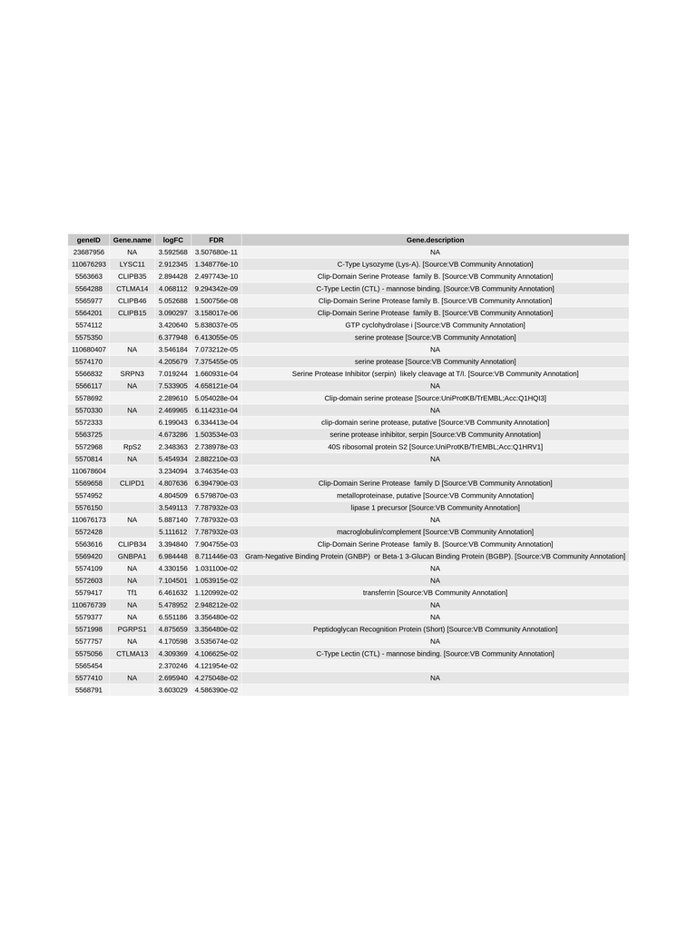

```r
Late <- makeContrasts((0.5*subtypeDengue6j + 0.5*subtypeRVF6j)-(1/3*subtypeMOCKA6j + 1/3*subtypeMOCKB6j + 1/3*subtypeMOCKC6j),levels=design1)
tr <- glmTreat(fit, contrast=Late, lfc=log2(3))
tmp  = topTags(tr,n=1000,p.value=0.05)
tmp$table$geneID = rownames(tmp$table)
tmp$table %>% left_join(.,Long_description,by="geneID") %>%
  filter(logFC>0) %>%
  write.xlsx(.,file="DE_results.xlsx", sheetName = "UP_DE_genes_latevirus_vs_latemock",append=T,row.names=F)
tmp$table %>% left_join(.,Long_description,by="geneID") %>%
  filter(logFC<0) %>%
  write.xlsx(.,file="DE_results.xlsx", sheetName ="DOWN_DE_genes_latevirus_vs_latemock",append=T,row.names=F)
uplate = tmp$table %>% left_join(.,Long_description,by="geneID") %>%
  filter(logFC>0) %>% select(c(6,7,1,5,6,8))
uplate %>%  ggtexttable(rows = NULL)
```

```r
ggsave("Figures/UP_LATE.pdf")
```

# Late versus early response

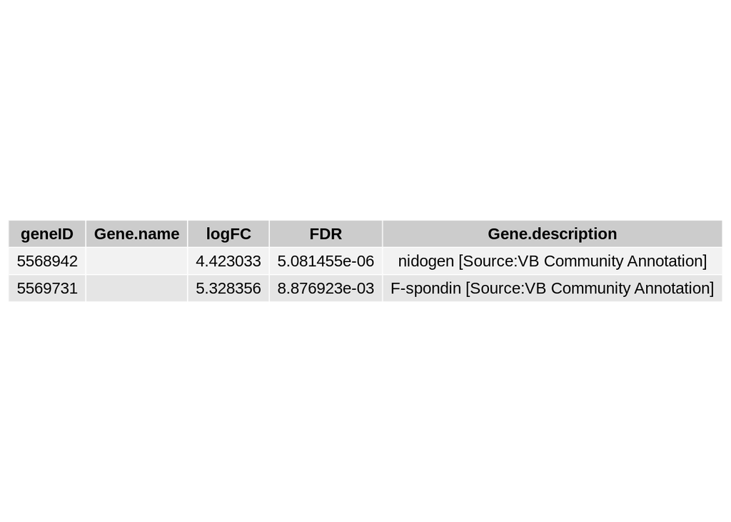

```r
Early <- makeContrasts((0.5*subtypeDengue6j + 0.5*subtypeRVF6j)-(0.5*subtypeDengue24h + 0.5*subtypeRVF24h),levels=design1)
DG = estimateDisp(DG,design1,robust = T)
fit <- glmQLFit(DG, design1, robust=TRUE)
tr <- glmTreat(fit, contrast=Early, lfc=log2(3))
tmp  = topTags(tr,n=1000,p.value=0.05)
tmp$table$geneID = rownames(tmp$table)
tmp$table %>% left_join(.,Long_description,by="geneID") %>%
  filter(logFC>0) %>%
  write.xlsx(.,file="DE_results.xlsx", sheetName = "UP_DE_genes_late_virus_vs_early_virus",append=T,row.names=F)
tmp$table %>% left_join(.,Long_description,by="geneID") %>%
  filter(logFC<0) %>%
  write.xlsx(.,file="DE_results.xlsx", sheetName =" DOWN_DE_genes_late_virus_vs_early_virus",append=T,row.names=F)
tmp$table %>% left_join(.,Long_description,by="geneID") %>%
  filter(logFC>0) %>% select(c(6,7,1,5,6,8)) %>%  ggtexttable(rows = NULL)
```

```r
ggsave("Figures/UP_virus_early-vs-late.pdf")
```

Only two genes significantly upregulated between early and late response. F-spondine (already seen in previous results but I am not able to ) and nidogene. The latter is also related to viral infection (https://www.ncbi.nlm.nih.gov/pmc/articles/PMC5636170/ see that spondin modifs are also cited in the article !) but is not upregulated when compared to mock infections in our data.

## Figures to check level of expression of UP genes (early and late)

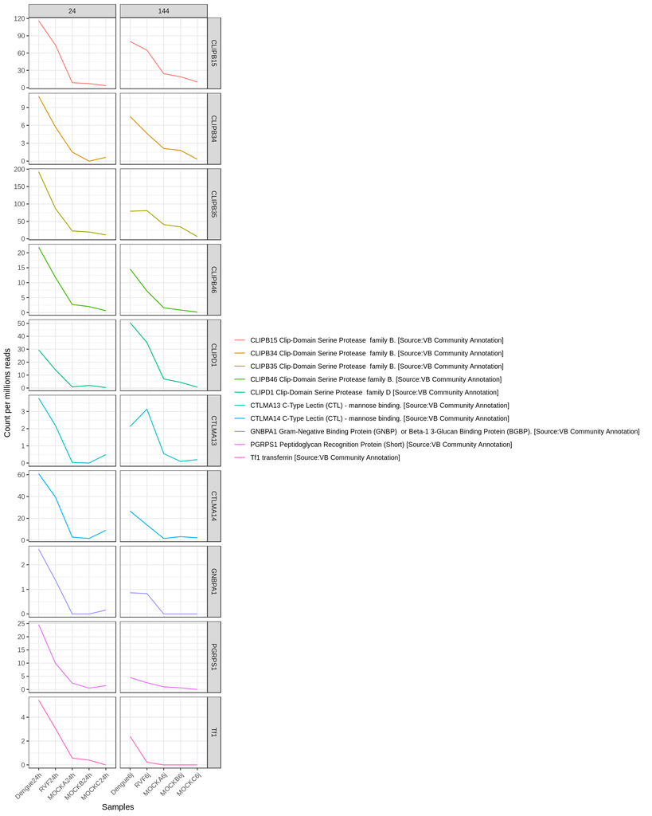

```r
eg = upearly %>% filter(Gene.name !="NA" & Gene.name !="") %>% select(geneID)
el = uplate %>% filter(Gene.name !="NA" & Gene.name !="") %>% select(geneID)
liste = intersect(eg,el)
#liste = union(eg,el)
liste = liste %>% mutate(geneID = as.character(geneID))
counts = cpm(DG$counts) %>% as.data.frame
counts$geneID = rownames(counts)
counts %>% filter(geneID %in% liste$geneID) %>% left_join(Long_description %>% select(geneID,Gene.name,Gene.description),by='geneID') %>%
  gather(sample,cpm,1:25) %>% left_join(infos %>% mutate(sample=name),by="sample") %>%
  group_by(geneID,Gene.name,Gene.description,subtype,time) %>% summarize(mcpm = mean(cpm)) %>%
  mutate(alldesc = paste(Gene.name, Gene.description," ")) %>%
  ggplot() + geom_line(aes(group=Gene.name,x=subtype,y=mcpm,color=alldesc)) + theme_bw() +
  facet_grid(Gene.name ~ time, scale = "free") + theme(axis.text.x = element_text(angle=45,hjust=1)) +
  scale_color_discrete(name="") + ylab("Count per millions reads") + xlab("Samples")
```

Here I kept list of genes up regulated in viral versus mock infection, late and early, and looked for the intersection of both lists. I filtered to keep only “known” genes. Counts per million in each samples is used to check for actual overexpression in samples infected by a virus.